Category

By Player

Distribution by Player

How does the grade distribution per player look like? I think that’s one of the first questions that came to my mind.

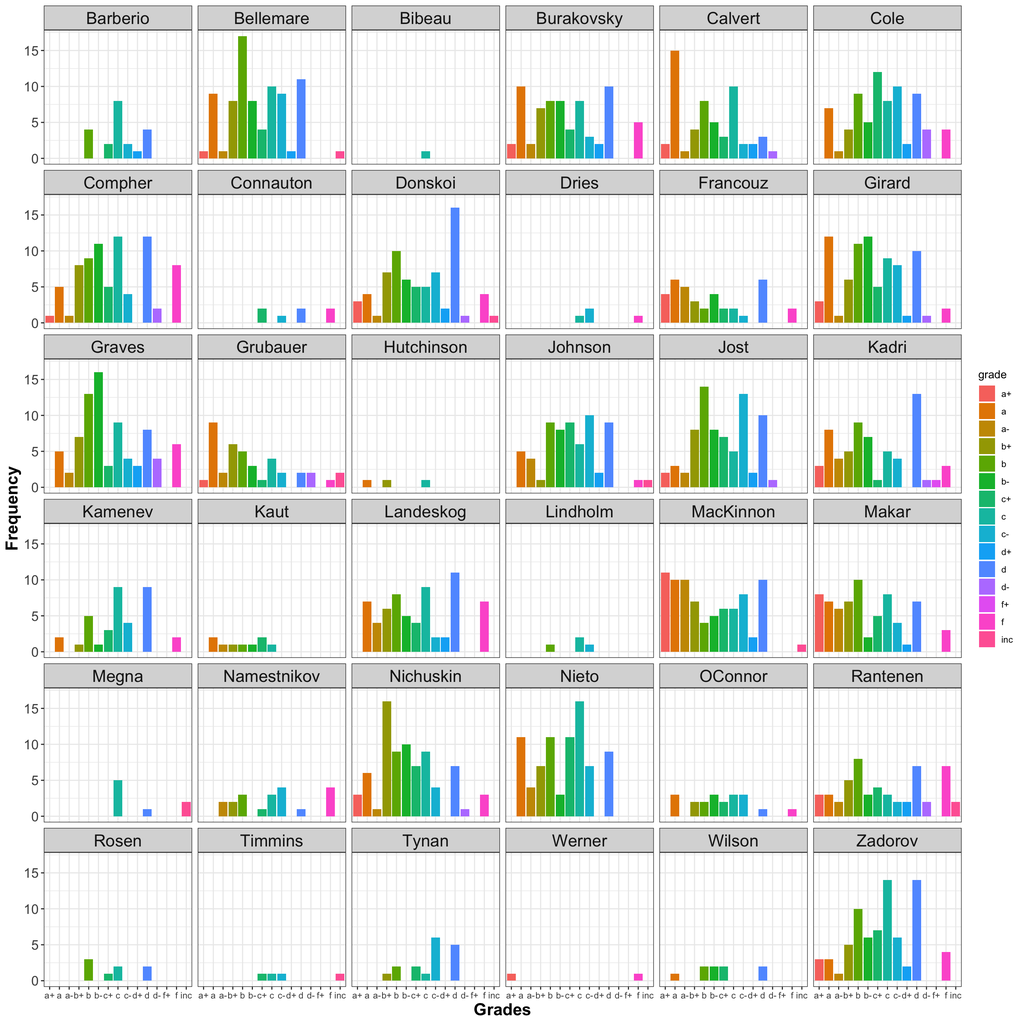

From this, you can kind of get an idea how each player fared. It’s also interesting to see how the distribution shapes differ between players. For example, some players received much more *partial grades* than others.Was it because more thought was put into them?  
It’s also intersting how some players tended to receive a “default” grade. *(Donskoi was given a **D** grade much more frequent than his other grades.)*  
I think this graphic - combined with the next graphic - tell more about the nature of player grades than anything else.

GPA by Player

Distributions are great. But it’s easier to see the overall grade of a player when mapped to a GPA  
This is one of my favorite graphics.

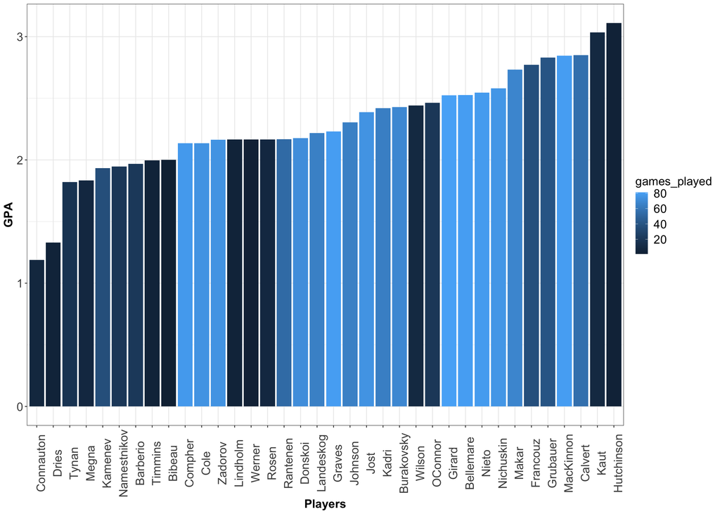

A few players didn’t play as many games *(Hutchinson, Kaut)*, so keep that in mind.  
But this graphic is very interesting. *Why is Calvert so high? Why is Compher so low?*

Distribution by Position

Here’s another graphic that’s related. How is the distribution by position?

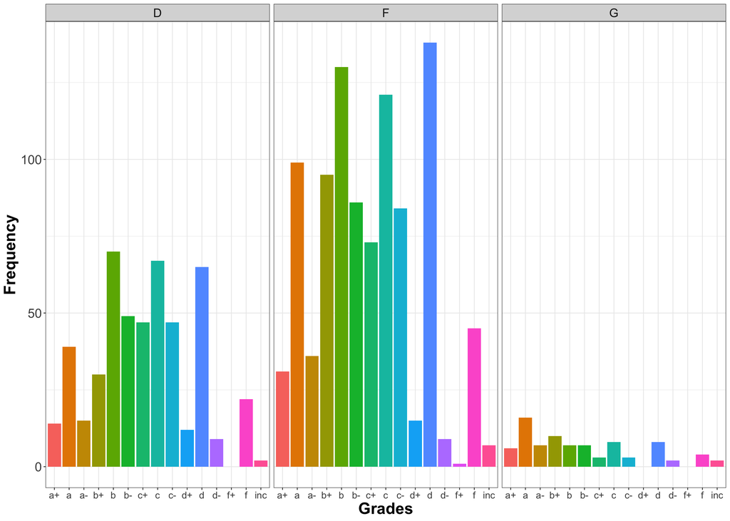